DS 6030 | Fall 2023 | University of Virginia

# Final Project: Generalized Additive Models (GAM)

Author

**Rachel Holman, Grace Zhang, Rose E.M.**

Published

November 13, 2023

```r
library(tidyverse)    # functions for data manipulation
library(ggplot2)
library(MASS)
library(dplyr)
library(GGally)
library(kableExtra)
library(DT)
```

# Introduction to Generalize Additive Models (GAM)

With a collection of 3900 records, this dataset encompasses various features related to customer shopping preferences, gathering essential information for businesses seeking to enhance their understanding of their customer base. The features include customer age, gender, purchase amount, preferred payment methods, frequency of purchases, and feedback ratings. Additionally, data on the type of items purchased, shopping frequency, preferred shopping seasons, and interactions with promotional offers is included.

https://www.kaggle.com/datasets/iamsouravbanerjee/customer-shopping-trends-dataset

- `Customer ID` - Unique identifier for each customer
- `Age` - Age of the customer
- `Gender` - Gender of the customer (Male/Female)
- `Item Purchased` - The item purchased by the customer
- `Category` - Category of the item purchased
- `Purchase Amount (USD)` - The amount of the purchase in USD
- `Location` - Location where the purchase was made
- `Size` - Size of the purchased item
- `Color` - Color of the purchased item
- `Season` - Season during which the purchase was made
- `Review Rating` - Rating given by the customer for the purchased item
- `Subscription Status` - Indicates if the customer has a subscription (Yes/No)
- `Shipping Type` - Type of shipping chosen by the customer
- `Discount Applied` - Indicates if a discount was applied to the purchase (Yes/No)
- `Promo Code Used` - Indicates if a promo code was used for the purchase (Yes/No)
- `Previous Purchases` - The total count of transactions concluded by the customer at the store, excluding the ongoing transaction
- `Payment Method` - Customer’s most preferred payment method
- `Frequency of Purchases` - Frequency at which the customer makes purchases (e.g., Weekly, Fortnightly, Monthly)

# Specialty of GAM:

# Advantages and Disadvantages:

The principal advantage of GAM is its ability to model highly complex nonlinear relationships when the number of potential predictors is large. The main disadvantage of GAM is its computational complexity; like other nonparametric methods, GAM has a high propensity for overfitting.

|  | Advantages of GAMs | Disadvantages of GAMs |
| --- | --- | --- |
| 1. | **Flexibility:** GAMs can model various relationships, including non-linear and complex patterns. | **Complexity:** GAMs can become computationally intensive for large datasets or high-dimensional problems. |
| 2. | **Interpretability:** They provide interpretable results, making understanding the relationships between predictors and the response easier. | **Data Requirements:** GAMs may require larger sample sizes to capture non-linear patterns effectively. |
| 3. | **Non-linearity:** GAMs can capture intricate, non-linear relationships that traditional linear models cannot represent. | **Sensitivity to Smoothing Parameters:** The choice of smoothing parameters can impact model results, requiring careful tuning. |
| 4. | **Regularization:** GAMs can incorporate regularization techniques to prevent overfitting and improve generalization. | **Model Selection:** Selecting the appropriate number and type of smooth terms can be challenging. |
| 5. | **Visualization:** The smooth functions in GAMs can be visually represented, aiding in model interpretation. | **Limited to Regression and Classification:** GAMs are primarily suited for regression and classification tasks and may not be suitable for more complex tasks like image recognition. |
| 6. | **Insensitive to Outliers:** GAM outliers do not have as strong of a global influence even if they have a local influence on fit. | **Wider confidence intervals and less powerful tests.** As a tradeoff for the high flexibility, GAMs generally have wider confidence intervals than simpler models. |

More disadvantages:

**Cannot model with non-additive relationships.** GAMs struggle in situations where the relationships between the features and the outcome variables are not additive. They do not capture situations where there are interactions between multiple features where one the value of one feature affects the relationship between another feature and the outcome variable natively.

**Not well known.** Not as commonly used or well known as many other supervised learning models. That means that collaborators may need to set aside some time to learn about the model before they can contribute meaningfully.

**Require some validation.** GAMs are highly flexible and can sometimes converge to solutions that do not make sense. It is generally recommended that you spend some time inspecting the results of your models to make sure that they make sense. Generalized additive models might not be the best option if you do not have bandwidth for this.

**Not guaranteed to converge.** One disadvantage of GAMs is that the models are not guaranteed to converge and you may need to experiment with different model training routines before you arrive on a model that does converge appropriately.

**Sensitive to predictors that are associated with one another.** Much like generalized linear models are sensitive to situations where multiple predictors are linearly correlated with one another, generalized additive models are also sensitive to situations where multiple predictors display similar patterns. Concurvity is a generalization of multicollinearity that is used to describe this specific situation.

**Does not natively handle missing values.** Another disadvantage of GAMs is that they do not natively handle missing values. Most implementations of generalized additive models require the user to select a method that will be used to handle missing data. While there are some more advanced options, the default option is usually to drop rows with missing values.

# R and Python packages for GAMs

# Data Cleaning and EDA

Before we start performing GAM for linear regression, we loaded our dataset and checked if there are any missing values, abnormal zeros, and NAs in the dataset.

```r
# import data
shopping_trend <- read.csv('shopping_trends_updated.csv')

datatable(shopping_trend)
```

|  | Customer.ID | Age | Gender | Item.Purchased | Category | Purchase.Amount..USD. | Location | Size | Color | Season | Review.Rating | Subscription.Status | Shipping.Type | Discount.Applied | Promo.Code.Used | Previous.Purchases | Payment.Method | Frequency.of.Purchases |
| --- | --- | --- | --- | --- | --- | --- | --- | --- | --- | --- | --- | --- | --- | --- | --- | --- | --- | --- |
| 1 | 1 | 55 | Male | Blouse | Clothing | 53 | Kentucky | L | Gray | Winter | 3.1 | Yes | Express | Yes | Yes | 14 | Venmo | Fortnightly |
| 2 | 2 | 19 | Male | Sweater | Clothing | 64 | Maine | L | Maroon | Winter | 3.1 | Yes | Express | Yes | Yes | 2 | Cash | Fortnightly |
| 3 | 3 | 50 | Male | Jeans | Clothing | 73 | Massachusetts | S | Maroon | Spring | 3.1 | Yes | Free Shipping | Yes | Yes | 23 | Credit Card | Weekly |
| 4 | 4 | 21 | Male | Sandals | Footwear | 90 | Rhode Island | M | Maroon | Spring | 3.5 | Yes | Next Day Air | Yes | Yes | 49 | PayPal | Weekly |
| 5 | 5 | 45 | Male | Blouse | Clothing | 49 | Oregon | M | Turquoise | Spring | 2.7 | Yes | Free Shipping | Yes | Yes | 31 | PayPal | Annually |
| 6 | 6 | 46 | Male | Sneakers | Footwear | 20 | Wyoming | M | White | Summer | 2.9 | Yes | Standard | Yes | Yes | 14 | Venmo | Weekly |
| 7 | 7 | 63 | Male | Shirt | Clothing | 85 | Montana | M | Gray | Fall | 3.2 | Yes | Free Shipping | Yes | Yes | 49 | Cash | Quarterly |
| 8 | 8 | 27 | Male | Shorts | Clothing | 34 | Louisiana | L | Charcoal | Winter | 3.2 | Yes | Free Shipping | Yes | Yes | 19 | Credit Card | Weekly |
| 9 | 9 | 26 | Male | Coat | Outerwear | 97 | West Virginia | L | Silver | Summer | 2.6 | Yes | Express | Yes | Yes | 8 | Venmo | Annually |
| 10 | 10 | 57 | Male | Handbag | Accessories | 31 | Missouri | M | Pink | Spring | 4.8 | Yes | 2-Day Shipping | Yes | Yes | 4 | Cash | Quarterly |

[output cut: 3890 more lines]

```r
#data type of variables
str(shopping_trend)
```

```
'data.frame':   3900 obs. of  18 variables:
 $ Customer.ID           : int  1 2 3 4 5 6 7 8 9 10 ...
 $ Age                   : int  55 19 50 21 45 46 63 27 26 57 ...
 $ Gender                : chr  "Male" "Male" "Male" "Male" ...
 $ Item.Purchased        : chr  "Blouse" "Sweater" "Jeans" "Sandals" ...
 $ Category              : chr  "Clothing" "Clothing" "Clothing" "Footwear" ...
 $ Purchase.Amount..USD. : int  53 64 73 90 49 20 85 34 97 31 ...
 $ Location              : chr  "Kentucky" "Maine" "Massachusetts" "Rhode Island" ...
 $ Size                  : chr  "L" "L" "S" "M" ...
 $ Color                 : chr  "Gray" "Maroon" "Maroon" "Maroon" ...
 $ Season                : chr  "Winter" "Winter" "Spring" "Spring" ...
 $ Review.Rating         : num  3.1 3.1 3.1 3.5 2.7 2.9 3.2 3.2 2.6 4.8 ...
 $ Subscription.Status   : chr  "Yes" "Yes" "Yes" "Yes" ...
 $ Shipping.Type         : chr  "Express" "Express" "Free Shipping" "Next Day Air" ...
 $ Discount.Applied      : chr  "Yes" "Yes" "Yes" "Yes" ...
 $ Promo.Code.Used       : chr  "Yes" "Yes" "Yes" "Yes" ...
 $ Previous.Purchases    : int  14 2 23 49 31 14 49 19 8 4 ...
 $ Payment.Method        : chr  "Venmo" "Cash" "Credit Card" "PayPal" ...
 $ Frequency.of.Purchases: chr  "Fortnightly" "Fortnightly" "Weekly" "Weekly" ...
```

```r
# check NAs
colSums(is.na(shopping_trend))
```

```
           Customer.ID                    Age                 Gender
                     0                      0                      0
        Item.Purchased               Category  Purchase.Amount..USD.
                     0                      0                      0
              Location                   Size                  Color
                     0                      0                      0
                Season          Review.Rating    Subscription.Status
                     0                      0                      0
         Shipping.Type       Discount.Applied        Promo.Code.Used
                     0                      0                      0
    Previous.Purchases         Payment.Method Frequency.of.Purchases
                     0                      0                      0
```

```r
# check zeros
colSums(shopping_trend == 0, na.rm = TRUE)
```

```
           Customer.ID                    Age                 Gender
                     0                      0                      0
        Item.Purchased               Category  Purchase.Amount..USD.
                     0                      0                      0
              Location                   Size                  Color
                     0                      0                      0
                Season          Review.Rating    Subscription.Status
                     0                      0                      0
         Shipping.Type       Discount.Applied        Promo.Code.Used
                     0                      0                      0
    Previous.Purchases         Payment.Method Frequency.of.Purchases
                     0                      0                      0
```

Then, we ran a quick exploratory data analysis by computing the correlation between numeric variables - `Age`, `Purchase.Amount..USD.`, ‘Review.Rating’, and ‘Previous.Purchases’.

```r
# correlation between numeric variables
num_corr_tb<- shopping_trend %>%
  #include dplyr::, otherwise dplyr would clash with MASS package
  dplyr::select(-Customer.ID, -Gender, -Item.Purchased, -Category, -Location,
                -Size, -Color, -Season, -Subscription.Status, -Shipping.Type,
                -Discount.Applied, -Promo.Code.Used, -Payment.Method,
                -Frequency.of.Purchases)


#num_corr_tb
datatable(cor(num_corr_tb))
```

|  | Age | Purchase.Amount..USD. | Review.Rating | Previous.Purchases |
| --- | --- | --- | --- | --- |
| Age | 1 | -0.01042364737868655 | -0.02194914807593323 | 0.04044453114289422 |
| Purchase.Amount..USD. | -0.01042364737868655 | 1 | 0.03077592307391425 | 0.008063412270587652 |
| Review.Rating | -0.02194914807593323 | 0.03077592307391425 | 1 | 0.004229099465270845 |
| Previous.Purchases | 0.04044453114289422 | 0.008063412270587652 | 0.004229099465270845 | 1 |

As the correlation table shown above, we did not see any strong correlation between these numeric variables.

```r
#one-hot coding
shopping_trend$Gender <- as.integer(factor(shopping_trend$Gender))-1
#shopping_trend$Item.Purchased <- as.integer(factor(shopping_trend$Item.Purchased)) -1
#shopping_trend$Category <- as.integer(factor(shopping_trend$Category)) -1
#shopping_trend$Location <- as.integer(factor(shopping_trend$Location)) -1
#shopping_trend$Size <- as.integer(factor(shopping_trend$Size)) -1
#shopping_trend$Color <- as.integer(factor(shopping_trend$Color)) -1
#shopping_trend$Season <- as.integer(factor(shopping_trend$Season)) -1
#shopping_trend$Shipping.Type  <- as.integer(factor(shopping_trend$Shipping.Type )) -1
#shopping_trend$Discount.Applied <- as.integer(factor(shopping_trend$Discount.Applied)) -1
#shopping_trend$Promo.Code.Used <- as.integer(factor(shopping_trend$Promo.Code.Used)) -1
#shopping_trend$Payment.Method <- as.integer(factor(shopping_trend$Payment.Method)) -1
#shopping_trend$Frequency.of.Purchases <- as.integer(factor(shopping_trend$Frequency.of.Purchases)) -1
shopping_trend$Subscription.Status <- as.integer(factor(shopping_trend$Subscription.Status)) -1

datatable(shopping_trend)
```

|  | Customer.ID | Age | Gender | Item.Purchased | Category | Purchase.Amount..USD. | Location | Size | Color | Season | Review.Rating | Subscription.Status | Shipping.Type | Discount.Applied | Promo.Code.Used | Previous.Purchases | Payment.Method | Frequency.of.Purchases |
| --- | --- | --- | --- | --- | --- | --- | --- | --- | --- | --- | --- | --- | --- | --- | --- | --- | --- | --- |
| 1 | 1 | 55 | 1 | Blouse | Clothing | 53 | Kentucky | L | Gray | Winter | 3.1 | 1 | Express | Yes | Yes | 14 | Venmo | Fortnightly |
| 2 | 2 | 19 | 1 | Sweater | Clothing | 64 | Maine | L | Maroon | Winter | 3.1 | 1 | Express | Yes | Yes | 2 | Cash | Fortnightly |
| 3 | 3 | 50 | 1 | Jeans | Clothing | 73 | Massachusetts | S | Maroon | Spring | 3.1 | 1 | Free Shipping | Yes | Yes | 23 | Credit Card | Weekly |
| 4 | 4 | 21 | 1 | Sandals | Footwear | 90 | Rhode Island | M | Maroon | Spring | 3.5 | 1 | Next Day Air | Yes | Yes | 49 | PayPal | Weekly |
| 5 | 5 | 45 | 1 | Blouse | Clothing | 49 | Oregon | M | Turquoise | Spring | 2.7 | 1 | Free Shipping | Yes | Yes | 31 | PayPal | Annually |
| 6 | 6 | 46 | 1 | Sneakers | Footwear | 20 | Wyoming | M | White | Summer | 2.9 | 1 | Standard | Yes | Yes | 14 | Venmo | Weekly |
| 7 | 7 | 63 | 1 | Shirt | Clothing | 85 | Montana | M | Gray | Fall | 3.2 | 1 | Free Shipping | Yes | Yes | 49 | Cash | Quarterly |
| 8 | 8 | 27 | 1 | Shorts | Clothing | 34 | Louisiana | L | Charcoal | Winter | 3.2 | 1 | Free Shipping | Yes | Yes | 19 | Credit Card | Weekly |
| 9 | 9 | 26 | 1 | Coat | Outerwear | 97 | West Virginia | L | Silver | Summer | 2.6 | 1 | Express | Yes | Yes | 8 | Venmo | Annually |
| 10 | 10 | 57 | 1 | Handbag | Accessories | 31 | Missouri | M | Pink | Spring | 4.8 | 1 | 2-Day Shipping | Yes | Yes | 4 | Cash | Quarterly |

[output cut: 3890 more lines]

# GAM for Linear Regression (Predicting Purchase Amount)

```r
# lets predict purchase.amount with age, gender, review.rating, and previous.purchases
```

### GAM Fit

For GAMs we will make use of the library gam in RStudio, so the first thing that we have to do is to install this package by executing install.packages(“gam”) once. Then we load the library.

```r
library(gam)
#library(mgcv)
```

The main function is gam(). Inside this function we can use any combination of non-linear and linear modelling of the various predictors. For example below we use a smoothing spline for `Age`, `Review.Rating`, and `Previous.Purchases`, and a simple linear model for the variable `Gender`. We then plot the contributions of each predictor using the command plot(). As we can see, GAMs are very useful as they estimate the contribution of the effects of each predictor.

```r
# fit the GAM model for linear regression
gam_lin = gam( Purchase.Amount..USD. ~ s(Age) + s(Review.Rating) +
                    s(Previous.Purchases) + Gender,
                  data = shopping_trend )

summary(gam_lin)
```

```
Call: gam(formula = Purchase.Amount..USD. ~ s(Age) + s(Review.Rating) +
    s(Previous.Purchases) + Gender, data = shopping_trend)
Deviance Residuals:
    Min      1Q  Median      3Q     Max
-42.666 -21.145   0.213  20.484  42.419

(Dispersion Parameter for gaussian family taken to be 560)

    Null Deviance: 2187330 on 3899 degrees of freedom
Residual Deviance: 2177070 on 3886 degrees of freedom
AIC: 35764

Number of Local Scoring Iterations: NA

Anova for Parametric Effects
                        Df  Sum Sq Mean Sq F value Pr(>F)
s(Age)                   1     222     222    0.40  0.529
s(Review.Rating)         1    1995    1995    3.56  0.059 .
s(Previous.Purchases)    1     154     154    0.27  0.600
Gender                   1     433     433    0.77  0.380
Residuals             3886 2177070     560
---
Signif. codes:  0 '***' 0.001 '**' 0.01 '*' 0.05 '.' 0.1 ' ' 1

Anova for Nonparametric Effects
                      Npar Df Npar F Pr(F)
(Intercept)
s(Age)                      3  0.939  0.42
s(Review.Rating)            3  1.861  0.13
s(Previous.Purchases)       3  1.637  0.18
Gender
```

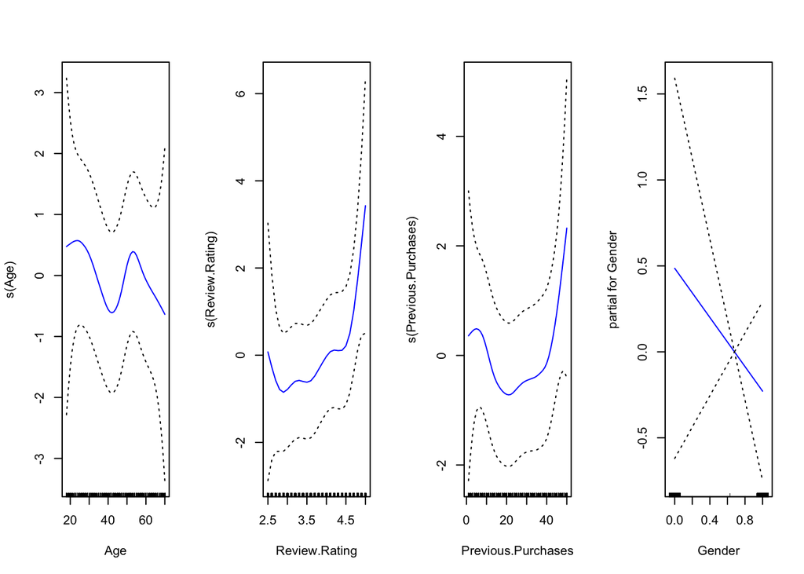

```r
par( mfrow = c(1,4) )
plot( gam_lin,  se = TRUE, col = "blue" )
```

Note that simply using `Gender` inside gam() is just fitting a linear model for this variables. However, one thing that we observe is that the `Gender` variable is binary as it only take the values of 0 and 1. This we can see from the x-axis of the `Gender` plot on the right above. So, it would be preferable to use a step function for this variable. In order to do this we have to change the variable to a factor. We first create a second object called shopping_trend1 (in order not to change the initial dataset shopping_trend) and then we use the command factor() to change the variable. Then we fit again the same model. As we can see below now gam() fits a step function for variable `Gender` which is more appropriate.

```r
# convert Gender to factor
shopping_trend1 = shopping_trend
shopping_trend1$Gender = factor(shopping_trend1$Gender)

# fit the GAM model for linear regression with updated Gender(factorized)
gam1_lin = gam( Purchase.Amount..USD. ~ s(Age) + s(Review.Rating) +
              s(Previous.Purchases) + Gender,
            data = shopping_trend1 )
summary(gam1_lin)
```

```
Call: gam(formula = Purchase.Amount..USD. ~ s(Age) + s(Review.Rating) +
    s(Previous.Purchases) + Gender, data = shopping_trend1)
Deviance Residuals:
    Min      1Q  Median      3Q     Max
-42.666 -21.145   0.213  20.484  42.419

(Dispersion Parameter for gaussian family taken to be 560)

    Null Deviance: 2187330 on 3899 degrees of freedom
Residual Deviance: 2177070 on 3886 degrees of freedom
AIC: 35764

Number of Local Scoring Iterations: NA

Anova for Parametric Effects
                        Df  Sum Sq Mean Sq F value Pr(>F)
s(Age)                   1     222     222    0.40  0.529
s(Review.Rating)         1    1995    1995    3.56  0.059 .
s(Previous.Purchases)    1     154     154    0.27  0.600
Gender                   1     433     433    0.77  0.380
Residuals             3886 2177070     560
---
Signif. codes:  0 '***' 0.001 '**' 0.01 '*' 0.05 '.' 0.1 ' ' 1

Anova for Nonparametric Effects
                      Npar Df Npar F Pr(F)
(Intercept)
s(Age)                      3  0.939  0.42
s(Review.Rating)            3  1.861  0.13
s(Previous.Purchases)       3  1.637  0.18
Gender
```

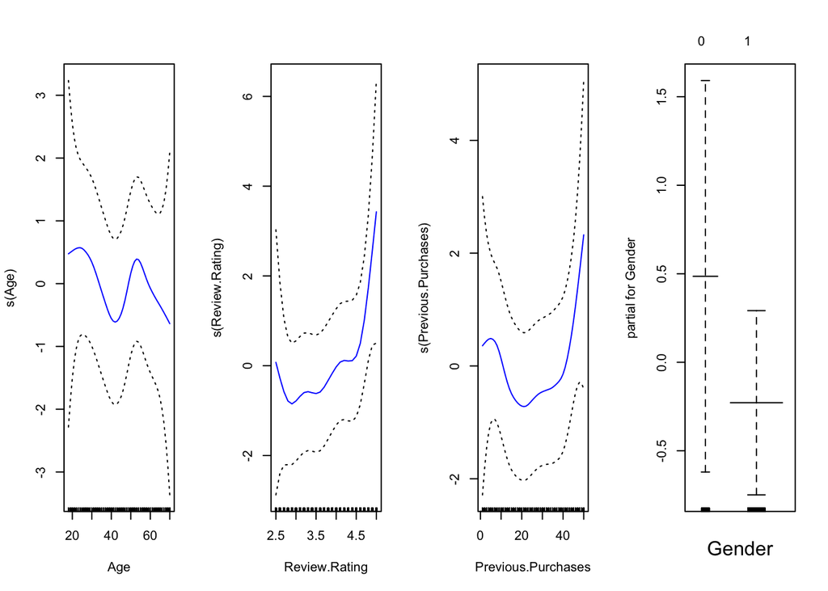

```r
par( mfrow = c(1,4) )
plot( gam1_lin,  se = TRUE, col = "blue" )
```

We can make predictions from gam objects, just like lm objects, using the predict() method for the class gam. Here we make predictions on some new data. Note that when assigning the value 0 to `Gender`, we enclose these values in “” since we informed R to treat `Gender` as a categorical factor with two levels - “0” and “1”.

```r
preds_gam_lin <- predict( gam1_lin,
                  newdata = data.frame( Gender = "0", Previous.Purchases = 27,
                                        Age = 30, Review.Rating = 3.8 )  )
preds_gam_lin
```

```
   1
59.7
```

### Linear Fit

It is important to note that one can produce a simple linear regression fit using the `gam()` function by simply not transforming any of the variables with smoothing or non-linear equations. Below, I will generate a simple linear regression to comanre with the GAM linear fit above.

```r
library(gam)
# linear fit
linear_mod = gam( Purchase.Amount..USD. ~ Age + Review.Rating +
                    Previous.Purchases + Gender,
                  data = shopping_trend1 )

summary(linear_mod)
```

```
Call: gam(formula = Purchase.Amount..USD. ~ Age + Review.Rating + Previous.Purchases +
    Gender, data = shopping_trend1)
Deviance Residuals:
     Min       1Q   Median       3Q      Max
-41.5511 -21.1442   0.0799  20.6913  42.0314

(Dispersion Parameter for gaussian family taken to be 561)

    Null Deviance: 2187330 on 3899 degrees of freedom
Residual Deviance: 2184434 on 3895 degrees of freedom
AIC: 35759

Number of Local Scoring Iterations: 2

Anova for Parametric Effects
                     Df  Sum Sq Mean Sq F value Pr(>F)
Age                   1     238     238    0.42  0.515
Review.Rating         1    2042    2042    3.64  0.056 .
Previous.Purchases    1     152     152    0.27  0.603
Gender                1     465     465    0.83  0.363
Residuals          3895 2184434     561
---
Signif. codes:  0 '***' 0.001 '**' 0.01 '*' 0.05 '.' 0.1 ' ' 1
```

We note that none of the predictor variables are significant for this model, just like in the GAM fit.

```r
preds_lin <- predict( linear_mod,
                  newdata = data.frame( Gender = "0", Previous.Purchases = 27,
                                        Age = 30, Review.Rating = 3.8 )  )
preds_lin
```

```
   1
60.6
```

The predicted purchase amount when using the simple linear regression is slightly higher than that found when using the GAM linear regression.

### Model Comparison

```r
AIC(linear_mod)
```

```
[1] 35759
```

```r
AIC(gam1_lin)
```

```
[1] 35764
```

The AIC values are vary similar with the GAM model having a slightly higher AIC indicating that in this case it may be better to use a simple linear regression.

```r
anova(linear_mod, gam1_lin, test="Chisq")
```

```
Analysis of Deviance Table

Model 1: Purchase.Amount..USD. ~ Age + Review.Rating + Previous.Purchases +
    Gender
Model 2: Purchase.Amount..USD. ~ s(Age) + s(Review.Rating) + s(Previous.Purchases) +
    Gender
  Resid. Df Resid. Dev Df Deviance Pr(>Chi)
1      3895    2184434
2      3886    2177070  9     7364     0.16
```

With a p-value of 0.1562, the anova test shows that the GAM model in this case had not improved the model significantly (p-value > 0.05).

# GAM for Logistic Regression (Predicting Subsription Status)

```r
# lets predict subscription.status with age, gender, review rating, and previous.purchases
```

```r
## convert Gender and Subscription.Status to factor
shopping_trend2 = shopping_trend
shopping_trend2$Gender = factor(shopping_trend2$Gender)
shopping_trend2$Subscription.Status = factor(shopping_trend2$Subscription.Status)

# fit the GAM model for logistic regression
gam_log = gam( Subscription.Status ~ s(Age) + s(Review.Rating) +
                    s(Previous.Purchases) + Gender,
                  data = shopping_trend2, family = binomial)

summary(gam_log)
```

```
Call: gam(formula = Subscription.Status ~ s(Age) + s(Review.Rating) +
    s(Previous.Purchases) + Gender, family = binomial, data = shopping_trend2)
Deviance Residuals:
     Min       1Q   Median       3Q      Max
-1.12035 -0.99052 -0.00037  1.28185  1.51683

(Dispersion Parameter for binomial family taken to be 1)

    Null Deviance: 4549 on 3899 degrees of freedom
Residual Deviance: 3548 on 3886 degrees of freedom
AIC: 3576

Number of Local Scoring Iterations: NA

Anova for Parametric Effects
                        Df Sum Sq Mean Sq F value Pr(>F)
s(Age)                   1      0   0.129    0.19   0.66
s(Review.Rating)         1      0   0.331    0.49   0.49
s(Previous.Purchases)    1      1   1.110    1.63   0.20
Gender                   1      0   0.057    0.08   0.77
Residuals             3886   2645   0.681

Anova for Nonparametric Effects
                      Npar Df Npar Chisq P(Chi)
(Intercept)
s(Age)                      3       5.50   0.14
s(Review.Rating)            3       3.05   0.38
s(Previous.Purchases)       3       4.89   0.18
Gender
```

According to the statistical outcome above, it is found that none of these variables have a significant effect on the subscription status, as all p-values are greater than 0.05.

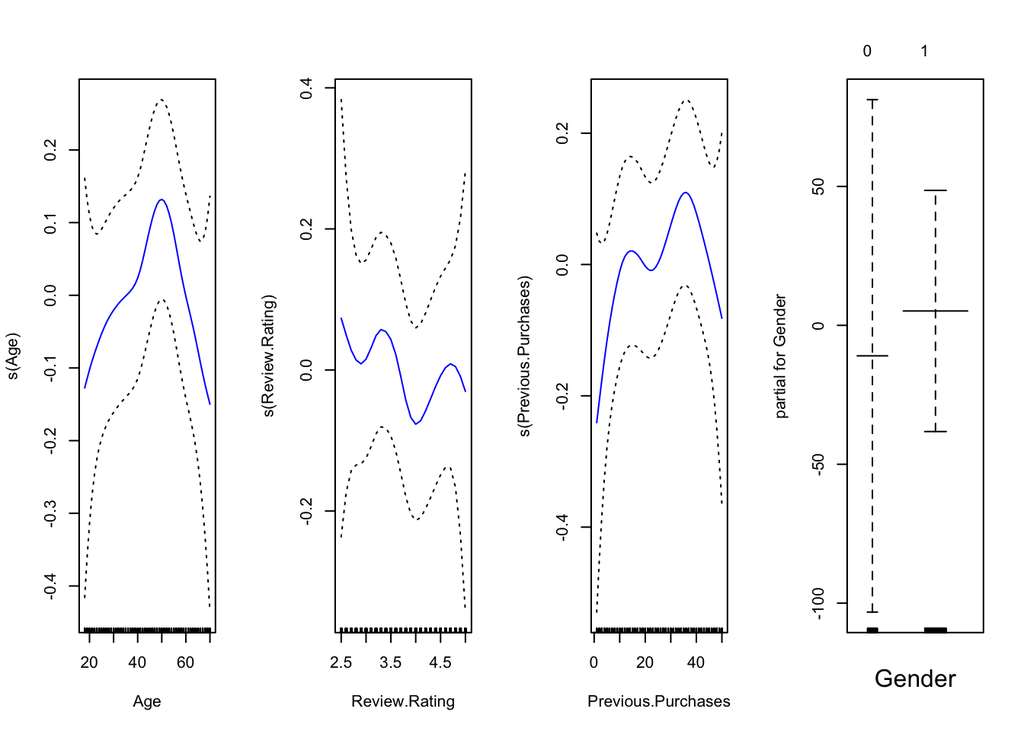

```r
par( mfrow = c(1,4) )
plot( gam_log,  se = TRUE, col = "blue" )
```

Now, we can make predictions from gam objects by using the predict() method for the class gam. Here we make predictions on some new data. Note that when assigning the value 1 to `Gender`, we enclose these values in “” since we informed R to treat `Gender` as a categorical factor with two levels - “0” and “1”.

```r
# prediction with GAM smoothing terms for logistic regression
preds_gam_log <- predict( gam_log,
                  newdata = data.frame( Gender = "1", Previous.Purchases = 30,
                                        Age = 20, Review.Rating = 2 )  )
preds_gam_log
```

```
     1
-0.267
```

### Logistic Fit

```r
# logistic fit
log_mod = gam( Subscription.Status ~ Age + Review.Rating +
                    Previous.Purchases + Gender,
                  data = shopping_trend2, family = binomial )

summary(log_mod)
```

```
Call: gam(formula = Subscription.Status ~ Age + Review.Rating + Previous.Purchases +
    Gender, family = binomial, data = shopping_trend2)
Deviance Residuals:
      Min        1Q    Median        3Q       Max
-1.056583 -0.999042 -0.000363  1.325997  1.414130

(Dispersion Parameter for binomial family taken to be 1)

    Null Deviance: 4549 on 3899 degrees of freedom
Residual Deviance: 3562 on 3895 degrees of freedom
AIC: 3572

Number of Local Scoring Iterations: 15

Anova for Parametric Effects
                     Df Sum Sq Mean Sq F value Pr(>F)
Age                   1      0   0.132    0.19   0.66
Review.Rating         1      0   0.442    0.65   0.42
Previous.Purchases    1      1   1.151    1.69   0.19
Gender                1      0   0.057    0.08   0.77
Residuals          3895   2652   0.681
```

```r
# prediction with logistic fit
preds_log <- predict( log_mod,
                  newdata = data.frame( Gender = "1", Previous.Purchases = 30,
                                        Age = 20, Review.Rating = 2 )  )
preds_log
```

```
    1
-0.36
```

### Model Comparison

```r
AIC(log_mod)
```

```
[1] 3572
```

```r
AIC(gam_log)
```

```
[1] 3576
```

```r
anova(log_mod, gam_log, test="Chisq")
```

```
Analysis of Deviance Table

Model 1: Subscription.Status ~ Age + Review.Rating + Previous.Purchases +
    Gender
Model 2: Subscription.Status ~ s(Age) + s(Review.Rating) + s(Previous.Purchases) +
    Gender
  Resid. Df Resid. Dev Df Deviance Pr(>Chi)
1      3895       3562
2      3886       3548  9     13.3     0.15
```

With a p-value of 0.1499, the GAM model in this case had not improved the model significantly (p-value > 0.05).